# Biostat 212a Homework 5

Due Mar 16, 2024 @ 11:59PM

Author

Yilin He and UID: 905789961

Published

March 16, 2024

## 1 ISL Exercise 9.7.1 (10pts)

1. This problem involves hyper-planes in two dimensions.

### 1.1 (a)

Sketch the hyperplane $1 + 3X_1 − X_2 = 0$. Indicate the set of points for which $1 + 3X_1 − X_2 > 0$, as well as the set of points for which $1 + 3X_1 − X_2 < 0$.

**Answer:**

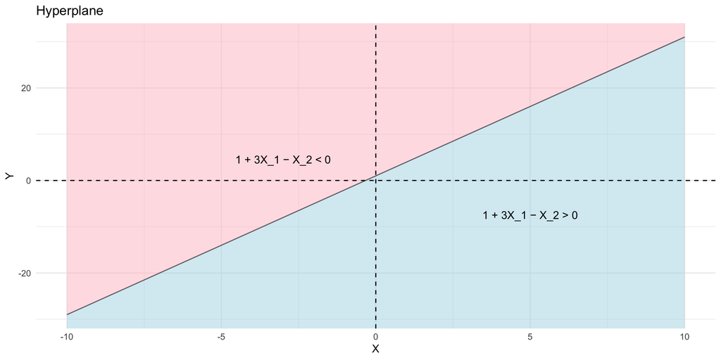

```r
library(ggplot2)

x <- seq(-10,10)
y <- 1 + 3 * x
data <- data.frame(x,y)

ggplot() +
  geom_line(aes(x,y)) +
  geom_ribbon(aes(x, ymin = -Inf, ymax = y), fill = "lightblue", alpha = 0.5) +
  geom_ribbon(aes(x, ymin = y, ymax = Inf), fill = "pink", alpha = 0.5) +
  labs(title = "Hyperplane", x = "X", y = "Y") +
  theme_minimal() +
  geom_hline(yintercept = 0, linetype = "dashed") +
  geom_vline(xintercept = 0, linetype = "dashed") +
  geom_text(aes(x = -3, y = 2, label = "1 + 3X_1 − X_2 < 0"), vjust = -1) +
  geom_text(aes(x = 5, y = -10, label = "1 + 3X_1 − X_2 > 0"), vjust = -1)
```

### 1.2 (b)

On the same plot, sketch the hyper-plane $−2 + X_1 + 2X_2 = 0$. Indicate the set of points for which $−2 + X_1 + 2X_2 > 0$, as well as the set of points for which $−2 + X_1 + 2X_2 < 0$.

**Answer:**

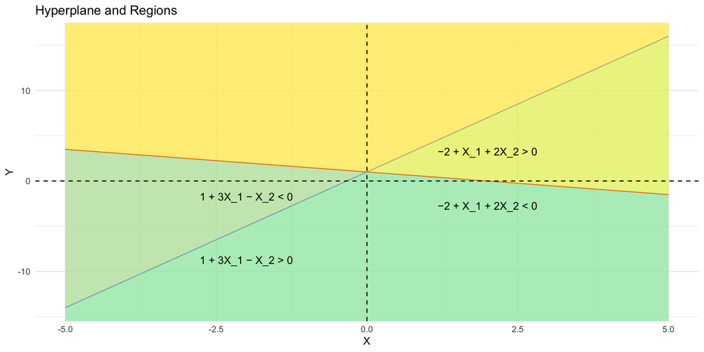

```r
x <- seq(-5,5,lenght.out = 100)
y1 <- 1 + 3 * x
y2 <- (2 - x) / 2
data1 <- data.frame(x, y = y1)
data2 <- data.frame(x, y = y2)

ggplot() +
  geom_line(data = data1, aes(x,y), color = "blue") +
  geom_ribbon(data = data1, aes(x, ymin = -Inf, ymax = y), fill = "lightblue", alpha = 0.5) +
  geom_ribbon(data = data1, aes(x, ymin = y, ymax = Inf), fill = "pink", alpha = 0.5) +

  geom_line(data = data2, aes(x,y), color = "red") +
  geom_ribbon(data = data2, aes(x, ymin = -Inf, ymax = y), fill = "lightgreen", alpha = 0.5) +
  geom_ribbon(data = data2, aes(x, ymin = y, ymax = Inf), fill = "yellow", alpha = 0.5) +


  labs(title = "Hyperplane and Regions", x = "X", y = "Y") +
  theme_minimal() +
  geom_hline(yintercept = 0, linetype = "dashed") +
  geom_vline(xintercept = 0, linetype = "dashed") +
  geom_text(aes(x = -2, y = -3, label = "1 + 3X_1 − X_2 < 0"), vjust = -1) +
  geom_text(aes(x = -2, y = -10, label = "1 + 3X_1 − X_2 > 0"), vjust = -1) +
  geom_text(aes(x = 2, y = 2, label = "−2 + X_1 + 2X_2 > 0"), vjust = -1) +
  geom_text(aes(x = 2, y = -4, label = "−2 + X_1 + 2X_2 < 0"), vjust = -1)
```

## 2 ISL Exercise 9.7.2 (10pts)

2. We have seen that in p = 2 dimensions, a linear decision boundary takes the form $\beta_0 +\beta_1X_1 + \beta_2X_2 = 0$. We now investigate a non-linear decision boundary.

### 2.1 (a)

Sketch the curve $(1 + X_1)^2 + (2 − X_2)^2 = 4$.

**Answer:**

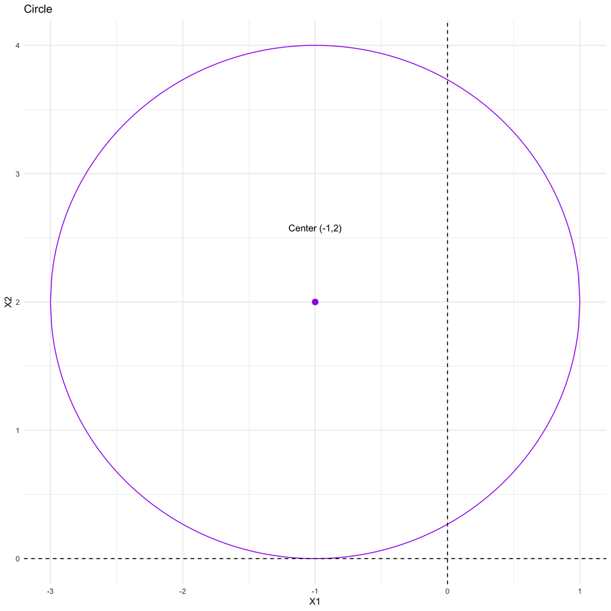

```r
x1 <- seq(-3, 1, length.out = 400)

x2_1 <- 2 + sqrt(4 - (1 + x1)^2)
x2_2 <- 2 - sqrt(4 - (1 + x1)^2)

x1_combined <- c(x1, rev(x1))
x2_combined <- c(x2_1, rev(x2_2))

circle <- data.frame(x1 = x1_combined, x2 = x2_combined)

ggplot() +
  geom_path(data = circle, aes(x = x1 , y = x2), color = "purple") +
  labs(title = "Circle", x = "X1", y = "X2") +
  geom_point(aes(x = -1, y = 2), color = "purple", size = 3) +
  geom_text(aes(x = -1, y = 2.5, label = "Center (-1,2)"), vjust = -1) +
  theme_minimal() +
  geom_hline(yintercept = 0, linetype = "dashed") +
  geom_vline(xintercept = 0, linetype = "dashed")
```

### 2.2 (b)

On your sketch, indicate the set of points for which $(1 + X_1)^2 + (2 − X_2)^2 > 4$, as well as the set of points for which $(1 + X_1)^2 + (2 − X_2)^2 ≤ 4$.

**Answer:**

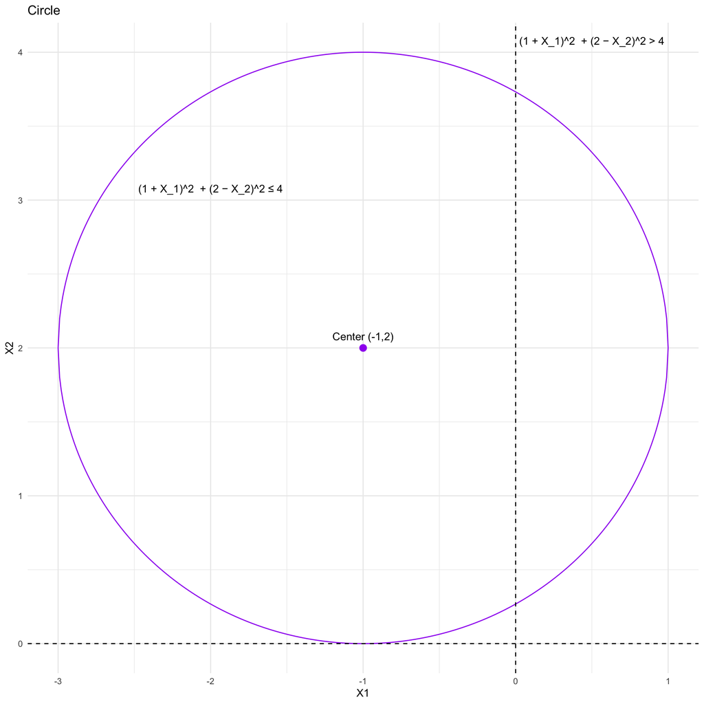

```r
x1 <- seq(-3, 1, length.out = 400)

x2_1 <- 2 + sqrt(4 - (1 + x1)^2)
x2_2 <- 2 - sqrt(4 - (1 + x1)^2)
x1_combined <- c(x1, rev(x1))
x2_combined <- c(x2_1, rev(x2_2))
circle <- data.frame(x1 = x1_combined, x2 = x2_combined)


ggplot() +
  geom_path(data = circle, aes(x = x1 , y = x2), color = "purple") +
  labs(title = "Circle", x = "X1", y = "X2") +
  geom_point(aes(x = -1, y = 2), color = "purple", size = 3) +
  geom_text(aes(x = -1, y = 2, label = "Center (-1,2)"), vjust = -1) +
  theme_minimal() +
  geom_hline(yintercept = 0, linetype = "dashed") +
  geom_vline(xintercept = 0, linetype = "dashed") +
  geom_text(aes(x = 0.5, y = 4, label = "(1 + X_1)^2  + (2 − X_2)^2 > 4"), vjust = -1) +
  geom_text(aes(x = -2, y = 3, label = "(1 + X_1)^2  + (2 − X_2)^2 ≤ 4"), vjust = -1)
```

### 2.3 (c)

Suppose that a classifier assigns an observation to the blue class if $(1 + X_1)^2 + (2 − X_2)^2 > 4$, and to the red class otherwise. To what class is the observation (0, 0) classified? (−1, 1)? (2, 2)? (3, 8)?

**Answer:**

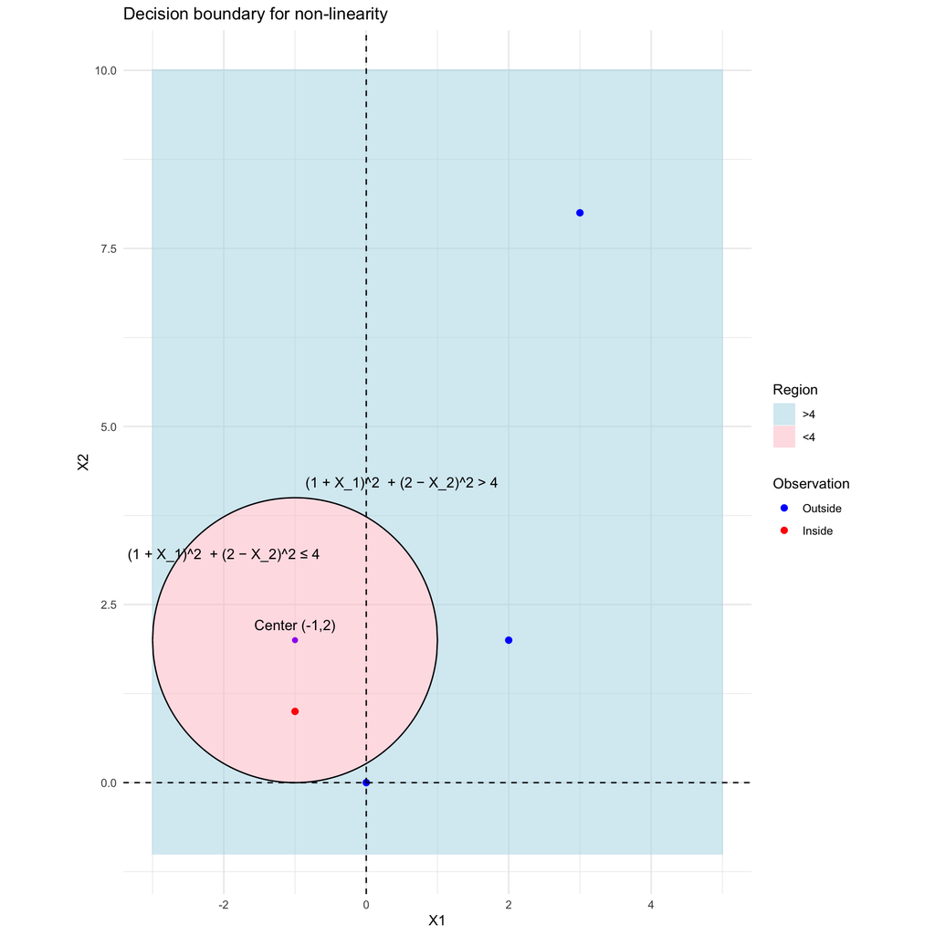

```r
obs <- data.frame(x_coord = c(0, -1, 2, 3),
                  y_coord = c(0,  1, 2, 8))

obs$inside <- ((1 + obs$x_coord)^2 +
               (2 - obs$y_coord)^2) <= 4


x1 <- seq(-3, 5, length.out = 400)
x2 <- seq(-1, 10, length.out = 400)
grid <- expand.grid(x1 = x1, x2 = x2)

grid$inside <- ((1 + grid$x1)^2 + (2 - grid$x2)^2) <= 4

ggplot() +
  geom_tile(data = grid,
            aes(x = x1,
                y = x2,
                fill = inside),
            alpha = .5) +
  geom_path(data = circle,
            aes(x = x1, y = x2)) +
  geom_point(aes(x = -1, y = 2), color = "purple") +
  geom_text(aes(x = -1, y = 2, label = "Center (-1,2)"), vjust = -1) +
  geom_point(data = obs,
             aes(x = x_coord,
                 y = y_coord,
                 color = inside),
             size = 2) +
  labs(title = "Decision boundary for non-linearity",
       x = "X1",
       y = "X2") +
  scale_fill_manual(values = c("lightblue", "pink"),
                    labels = c(">4", "<4"),
                    name = "Region") +
  scale_color_manual(values = c("blue", "red"),
                     labels = c("Outside", "Inside"),
                     name = "Observation") +
  theme_minimal() +
  geom_hline(yintercept = 0, linetype = "dashed") +
  geom_vline(xintercept = 0, linetype = "dashed") +
  geom_text(aes(x = 0.5, y = 4, label = "(1 + X_1)^2  + (2 − X_2)^2 > 4"), vjust = -1) +
  geom_text(aes(x = -2, y = 3, label = "(1 + X_1)^2  + (2 − X_2)^2 ≤ 4"), vjust = -1) +
  coord_fixed()
```

### 2.4 (d)

Argue that while the decision boundary in (c) is not linear in terms of $X_1$ and $X_2$, it is linear in terms of $X_1$, $X_1^2$, $X_2$, and $X_2^2$.

**Answer:**

$$\begin{align*}
(1 + 2X_1 + X_1^2) + (4 - 4X_2 + X^2_2) &= 4 \\
(1 + 2X_1 + X_1^2) + (4 - 4X_2 + X^2_2) - 4 &= 0 \\
1 + 2X_1 - 4X_2 + X_1^2 + X^2_2 &= 0 \\
\end{align*}$$

The decision boundary is linear in terms of $X_1$, $X_1^2$, $X_2$, and $X_2^2$.

## 3 Support vector machines (SVMs) on the `Carseats` data set (30pts)

Follow the machine learning workflow to train support vector classifier (same as SVM with linear kernel), SVM with polynomial kernel (tune the degree and regularization parameter $C$), and SVM with radial kernel (tune the scale parameter $\gamma$ and regularization parameter $C$) for classifying `Sales<=8` versus `Sales>8`. Use the same seed as in your HW4 for the initial test/train split and compare the final test AUC and accuracy to those methods you tried in HW4.

```r
carseats <- Carseats %>%
  mutate(Sales = ifelse(Sales > 8, "Low", "High")) %>%
  drop_na()
```

```r
# 3 Initial split into test and non-test sets
set.seed(101)
data_split <- initial_split(carseats,
                            strata = "Sales",
                            prop = 0.75)
data_split
```

```
<Training/Testing/Total>
<300/100/400>
```

```r
data_other <- training(data_split)
dim(data_other)
```

```
[1] 300  11
```

```r
data_test <- testing(data_split)
dim(data_test)
```

```
[1] 100  11
```

```r
# 4 recipe (R)
svm_recipe <-
  recipe(Sales ~ .,
         data = data_other
         ) %>%
  step_dummy(all_nominal_predictors()) %>%
  step_zv(all_numeric_predictors()) %>%
  step_normalize(all_numeric_predictors())
svm_recipe
```

### 3.1 SVM with linear kernel

```r
# 5 Model
svm_linear_mod <-
  svm_linear(
    mode = "classification",
    cost = tune()
) %>%
  set_engine("kernlab")
```

```r
# 6 workflow (R)
svm_linear_wf <- workflow() %>%
  add_recipe(svm_recipe) %>%
  add_model(svm_linear_mod)
```

```r
# 7 Tuning grid
param_grid1 <- grid_regular(
  cost(range = c(-3, 2)),
  levels = c(5)
  )
```

```r
# 8 Cross-validation (CV)
## Set cross-validation partitions
set.seed(101)
folds <- vfold_cv(data_other, v = 5)

## Fit cross-validation
svm_linear_fit <-
  svm_linear_wf %>%
  tune_grid(
    resamples = folds,
    grid = param_grid1,
    metrics = metric_set(roc_auc, accuracy)
  )
```

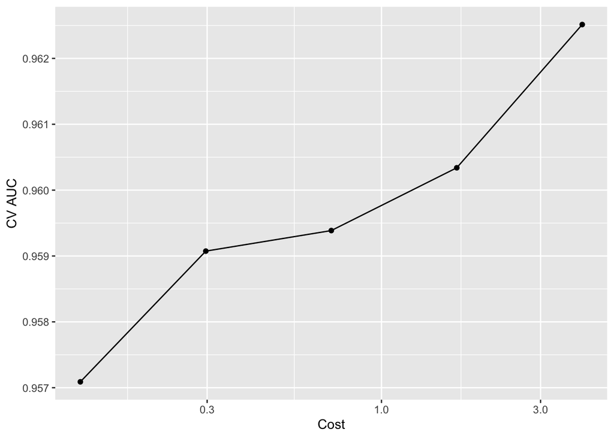

```r
## Visualize CV results
svm_linear_fit %>%
  collect_metrics() %>%
  filter(.metric == "roc_auc") %>%
  ggplot(aes(x = cost, y = mean)) +
  geom_line() +
  geom_point() +
  labs(x = "Cost",
       y = "CV AUC") +
  scale_x_log10()
```

The best model is selected based on the highest AUC.

```r
## Let’s select the best model.
best_linear <- svm_linear_fit %>%
  select_best("roc_auc")

# 9 Finalize our model
## Final workflow
final_linear_wf <-
  svm_linear_wf %>%
  finalize_workflow(
    best_linear
  )

## fit the whole training set, then predict test
final_linear_fit <-
  final_linear_wf %>%
  last_fit(data_split)

## test metrics
final_linear_fit %>%
  collect_metrics()
```

```
# A tibble: 2 × 4
  .metric  .estimator .estimate .config
  <chr>    <chr>          <dbl> <chr>
1 accuracy binary         0.9   Preprocessor1_Model1
2 roc_auc  binary         0.946 Preprocessor1_Model1
```

### 3.2 SVM with polynomial kernel

```r
# 5 Model
svm_polynomial_mod <-
  svm_poly(
    mode = "classification",
    cost = tune(),
    degree = tune()
  ) %>%
  set_engine("kernlab")
```

```r
# 6 workflow (R)
svm_polynomial_wf <- workflow() %>%
  add_recipe(svm_recipe) %>%
  add_model(svm_polynomial_mod)
```

```r
# 7 Tuning grid
param_grid2 <- grid_regular(
  cost(range = c(-3, 2)),
  degree(range = c(1, 5)),
  levels = c(5)
  )
```

```r
# 8 Cross-validation (CV)
## Set cross-validation partitions
set.seed(101)
folds <- vfold_cv(data_other, v = 5)

## Fit cross-validation
svm_polynomial_fit <-
  svm_polynomial_wf %>%
  tune_grid(
    resamples = folds,
    grid = param_grid2,
    metrics = metric_set(roc_auc, accuracy)
  )
```

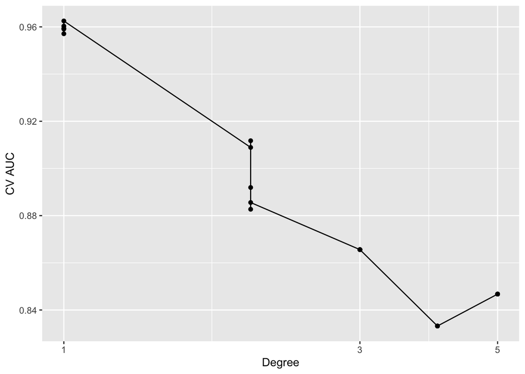

```r
svm_polynomial_fit %>%
  collect_metrics() %>%
  filter(.metric == "roc_auc") %>%
  ggplot(aes(x = degree, y = mean)) +
  geom_line() +
  geom_point() +
  labs(x = "Degree",
       y = "CV AUC") +
  scale_x_log10()
```

```r
## Let’s select the best model.
best_polynomial <- svm_polynomial_fit %>%
  select_best("roc_auc")

# 9 Finalize our model
## Final workflow
final_polynomial_wf <-
  svm_polynomial_wf %>%
  finalize_workflow(
    best_polynomial
  )

## fit the whole training set, then predict test
final_polynomial_fit <-
  final_polynomial_wf %>%
  last_fit(data_split)

## test metrics
final_polynomial_fit %>%
  collect_metrics()
```

```
# A tibble: 2 × 4
  .metric  .estimator .estimate .config
  <chr>    <chr>          <dbl> <chr>
1 accuracy binary         0.9   Preprocessor1_Model1
2 roc_auc  binary         0.946 Preprocessor1_Model1
```

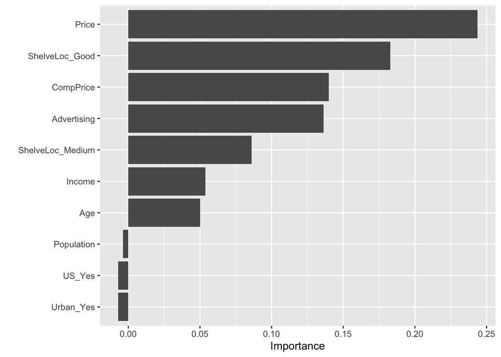

```r
set.seed(101)
split_obj <- initial_split(data = carseats,
                           prop = 0.7,
                           strata = Sales)
train <- training(split_obj)
test <- testing(split_obj)


# Create the recipe
recipe(Sales ~ ., data = train) %>%
  step_dummy(all_nominal_predictors()) %>%
  step_zv(all_numeric_predictors()) %>%
  step_normalize(all_numeric_predictors()) %>%
  prep() -> recipe_obj

# Bake
train <- bake(recipe_obj, new_data=train)
test <- bake(recipe_obj, new_data=test)

final_polynomial_fit %>%
  pluck(".workflow", 1) %>%
  extract_fit_parsnip() %>%
  vip(method = "permute",
      target = "Sales",
      metric = "accuracy",
      pred_wrapper = kernlab::predict, train = train)
```

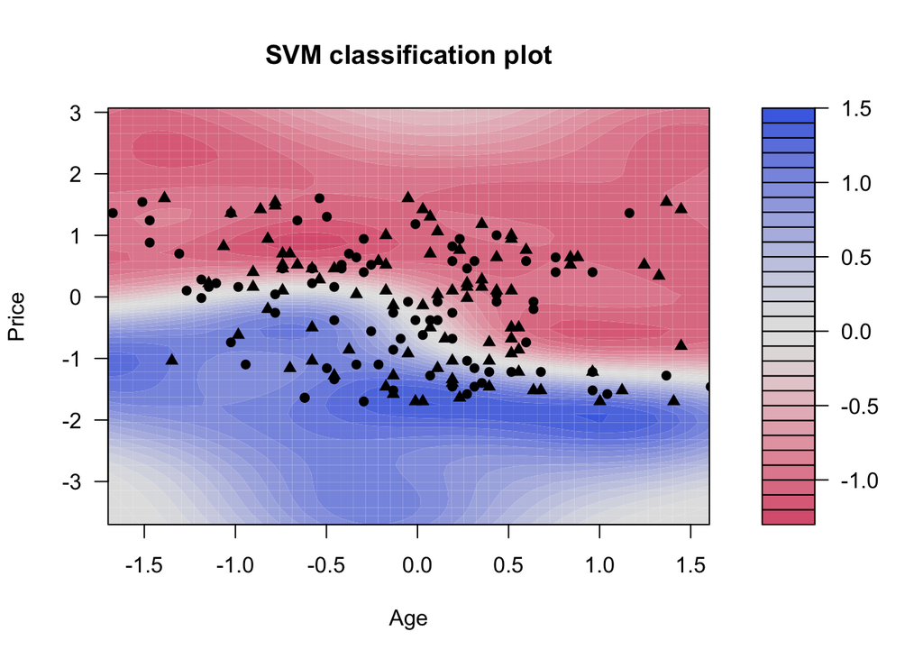

```r
#Create a classification plot
svm_rbf_spec <- svm_rbf() %>%
  set_engine("kernlab") %>%
  set_mode("classification")

svm_rbf_fit <- svm_rbf_spec %>%
  fit(Sales ~., data = train[,c("Price", "Age", "Sales")])

svm_rbf_fit %>%
  extract_fit_engine() %>%
  plot()
```

### 3.3 SVM with radial kernel

```r
# 5 Model
svm_radial_mod <-
  svm_rbf(
    mode = "classification",
    cost = tune(),
    rbf_sigma = tune()
  ) %>%
  set_engine("kernlab")
```

```r
# 6 workflow (R)
svm_radial_wf <- workflow() %>%
  add_recipe(svm_recipe) %>%
  add_model(svm_radial_mod)
```

```r
# 7 Tuning grid
param_grid3 <- grid_regular(
  cost(range = c(-8, 5)),
  rbf_sigma(range = c(-5, -3)),
  levels = c(14, 5)
  )
```

```r
# 8 Cross-validation (CV)
## Set cross-validation partitions
set.seed(101)
folds <- vfold_cv(data_other, v = 5)

## Fit cross-validation
svm_radial_fit <-
  svm_radial_wf %>%
  tune_grid(
    resamples = folds,
    grid = param_grid3,
    metrics = metric_set(roc_auc, accuracy)
  )
```

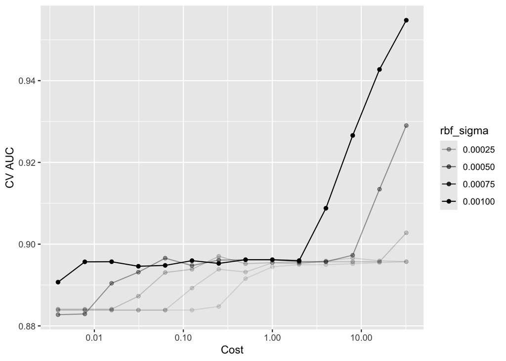

```r
svm_radial_fit %>%
  collect_metrics() %>%
  filter(.metric == "roc_auc") %>%
  ggplot(aes(x = cost, y = mean, alpha = rbf_sigma)) +
  geom_line(aes(group = rbf_sigma)) +
  geom_point() +
  labs(x = "Cost",
       y = "CV AUC") +
  scale_x_log10()
```

The different shades of lines represent various rbf_sigma values, a parameter that determines the model’s behavior. The single training example’s influence is determined by the value of the cost. The AUC shows the most significant increase with the darkest line, which has a value of .001, as the cost increases.

```r
## Let’s select the best model.
best_radial <- svm_radial_fit %>%
  select_best("roc_auc")

# 9 Finalize our model
## Final workflow
final_radial_wf <-
  svm_radial_wf %>%
  finalize_workflow(
    best_radial
  )


## fit the whole training set, then predict test
final_radial_fit <-
  final_radial_wf %>%
  last_fit(data_split)

## test metrics
final_radial_fit %>%
  collect_metrics()
```

```
# A tibble: 2 × 4
  .metric  .estimator .estimate .config
  <chr>    <chr>          <dbl> <chr>
1 accuracy binary         0.89  Preprocessor1_Model1
2 roc_auc  binary         0.945 Preprocessor1_Model1
```

## 4 Bonus (10pts)

Let
$$f(X) = \beta_0 + \beta_1 X_1 + \cdots + \beta_p X_p = \beta_0 + \beta^T X.$$
Then $f(X)=0$ defines a hyperplane in $\mathbb{R}^p$. Show that $f(x)$ is proportional to the signed distance of a point $x$ to the hyperplane $f(X) = 0$.

**Answer**: Given the defined by $f(X) = \beta_0 + \beta^T X = 0$ in $\mathbb{R}^p$, the function $f(x)$ evaluats to:
$$f(x) = \beta_0 + \beta^T x$$
where $X_0$ is a point on the hyperplane. The normal vector to the hyperplane is $\beta$. The equation of the hyperplane can be rewritten as
$$\beta_0 = -\beta^T X_0 \\$$

than plug in $f(x)$, we have
$$f(x) = \beta_0 + \beta^T x \\
= -\beta^T X_0 + \beta^T x \\
= \beta^T (x - X_0)$$
Thus,
$$\frac{\beta^T (x - X_0)}{\|\beta\|}
= \frac{f(x)}{\|\beta\|} = d \\$$
where $d$ is the signed distance of a point $x$ to the hyperplane $f(X) = 0$. Therefore, $f(x)$ is proportional to the signed distance of a point $x$ to the hyper-plane $\|\beta\|^{-1}$.

Thus, $f(x)$ is proportional to the signed distance of a point $x$ to the hyperplane $f(X) = 0$.